# 5 Centro y dispersión de un grupo de matrices

**NotaEn este capítulo**

**Pregunta.** ¿Cuál es el centro de un grupo de matrices y cuánto se dispersa?

**Objetivos.** Definir el centro de $N$ covarianzas para cada una de las tres geometrías del capítulo 4 como un único problema de minimización, demostrar qué propiedades tiene cada centro, linealizar el grupo en el espacio tangente controlando la distorsión y entender qué conserva y qué borra el re-centrado cuando se comparan sesiones.

**Prerrequisitos.** Capítulo 4 (distancias, geodésicas, invariancia afín) y, para la motivación, capítulo 2.

**Código.** Las funciones del paquete (`distance`, `expm`, `logm`, `sqrtm`, `invsqrtm`) hacen los cálculos. Las aplicaciones $\Exp_M$ y $\Log_M$, la media de Karcher y la vectorización son provisionales y viven en el capítulo; pasarán a `NeuroRiemann.jl` cuando lo autorices.

## 5.1 La pregunta

Un grupo de $N$ covarianzas (las épocas de una visita, las visitas de un paciente, los pacientes de un grupo) necesita un **resumen**: un centro y una medida de cuánto se dispersan alrededor de él. Con números, el centro es la media, es decir, el punto que minimiza la suma de cuadrados de las distancias. Esa descripción vale en cualquier espacio con distancia, y es lo que hace falta aquí.

**Definición 5.1 (Media y varianza de Fréchet)** Sea $d$ una de las tres distancias del capítulo 4 y $P_1,\dots,P_N\in\SPD_n$. Una **media de Fréchet** es un minimizador de
$$F_d(M)=\frac1N\sum_{i=1}^Nd(M,P_i)^2 ,$$
y la **varianza de Fréchet** es el valor mínimo $\sigma_d^2=\min_MF_d(M)$.

Cada geometría da, pues, un centro distinto, y no es una cuestión de gusto: es la misma pregunta con tres nociones de diferencia. Cuando $N$ vale $2$, el centro es el punto medio de la geodésica (capítulo 4).

## 5.2 Tres centros

**Proposición 5.1 (Los centros euclídeo y log-euclídeo son explícitos)** Para $P_1,\dots,P_N\in\SPD_n$, el único minimizador de $F_{d_E}$ es la media aritmética $\bar P=\tfrac1N\sum_iP_i$, y el único minimizador de $F_{\dLE}$ es $\Expm\big(\tfrac1N\sum_i\Logm P_i\big)$. Demostrado

*Demostración*. $F_{d_E}(M)=\tfrac1N\sum_i\|M-P_i\|_F^2$ es una función cuadrática estrictamente convexa de $M$ en el espacio euclídeo $\Sym_n$, con mínimo en la media aritmética (que es SPD, por ser combinación convexa de matrices SPD). Para la log-euclídea, $\Logm$ es una isometría de $(\SPD_n,\dLE)$ sobre $(\Sym_n,\|\cdot\|_F)$, así que $F_{\dLE}(M)=\tfrac1N\sum_i\|\Logm M-\Logm P_i\|_F^2$ se minimiza en $\Logm M=\tfrac1N\sum_i\Logm P_i$.

La media aritmética es, como se vio en el capítulo 2, la covarianza de los datos agregados. Para la afín-invariante no hay fórmula cerrada, pero sí una teoría completa. Se usan las aplicaciones
$$\Exp_M(X)=M^{1/2}\,\Expm\big(M^{-1/2}XM^{-1/2}\big)\,M^{1/2},\qquad
\Log_M(P)=M^{1/2}\,\Logm\big(M^{-1/2}PM^{-1/2}\big)\,M^{1/2},
\tag{5.1}$$
con $X\in\Sym_n$: $\Exp_M(t\Log_MP)=M^{1/2}\big(M^{-1/2}PM^{-1/2}\big)^tM^{1/2}$ es la geodésica $\gamma_{AI}(t)$ de $M$ a $P$ del capítulo 4. Atención: estas son las aplicaciones **riemannianas** (con punto base $M$), no las funciones matriciales $\Expm$ y $\Logm$ del apéndice C.

**Proposición 5.2 (La media afín-invariante existe, es única y se caracteriza por un punto fijo)** Para $P_1,\dots,P_N\in\SPD_n$, $F_{\dAI}$ tiene un único minimizador $M_{AI}$ (la media de Karcher o geométrica), y es el único punto que cumple
$$\sum_{i=1}^N\Logm\big(M^{-1/2}P_iM^{-1/2}\big)=0 .
\tag{5.2}$$
Citado (Moakher 2005; Bhatia 2007, cap. 6; Karcher 1977) [VERIFICAR el enunciado exacto de Karcher en la fuente]

La unicidad se debe a la curvatura no positiva de $(\SPD_n,\dAI)$. La **curvatura seccional** mide cuánto se separan las geodésicas respecto del caso plano: con curvatura $\le0$ lo hacen al menos tan rápido como en el plano. Una variedad riemanniana completa, simplemente conexa y de curvatura seccional $\le0$ se llama **de Hadamard**, y $\SPD_n$ con $\dAI$ lo es: es el espacio simétrico $\mathrm{GL}(n)/\mathrm{O}(n)$ Citado (Bhatia 2007). Lo que se necesita de ello es el teorema siguiente.

**Teorema 5.1 (Cartan–Hadamard)** En una variedad de Hadamard, la exponencial $\Exp_p$ es un difeomorfismo de $T_p\mathcal M$ sobre $\mathcal M$ para todo $p$. En particular, dos puntos cualesquiera se unen por **una única** geodésica, y esa geodésica minimiza la longitud. Citado (Carmo 1992; Lee 2018)

Con él, la existencia y la unicidad del minimizador de $F_{\dAI}$ son un caso del resultado de Karcher para variedades de curvatura no positiva. En general, $\Exp_p(v)$ es el punto que se alcanza en $t=1$ siguiendo la geodésica que sale de $p$ con velocidad $v$, y $\Log_p$ es su inversa; la ecuación 5.1 es su forma en $\SPD_n$. El **transporte paralelo** lleva un vector tangente de un punto a otro a lo largo de una curva y es una isometría entre los espacios tangentes; en el re-centrado de más abajo aparece una de sus consecuencias. La ecuación 5.2 dice que, vistos desde $M$ y «blanqueados», los $N$ puntos suman cero en el espacio tangente. Sugiere el algoritmo:

**Algoritmo** (media afín-invariante por punto fijo):

```
Entrada: P₁,…,P_N ∈ SPD(n), tolerancia ε
1. M ← media aritmética de los P_i
2. repetir:
     S ← (1/N) Σ_i log( M^{-1/2} P_i M^{-1/2} )         # vector tangente medio, blanqueado
     M ← M^{1/2} exp(S) M^{1/2}                         # M ← Exp_M(M^{1/2} S M^{1/2})
   hasta ‖S‖_F < ε
3. devolver M
Coste por iteración: N descomposiciones espectrales simétricas, O(N n³).
```

El criterio de parada es la norma de la ecuación 5.2 dividida por $N$. En este capítulo se comprueba que converge en los ejemplos; las condiciones teóricas de convergencia no se demuestran aquí.

Las propiedades que importan para EEG se deducen de la unicidad:

**Proposición 5.3 (Equivarianza por congruencia e invariancia de la varianza)** Para todo $W\in\GL(n)$, $M_{AI}(WP_1W^\top,\dots,WP_NW^\top)=W\,M_{AI}(P_1,\dots,P_N)\,W^\top$ y la varianza de Fréchet no cambia: $\sigma_{\dAI}^2(WP_iW^\top)=\sigma_{\dAI}^2(P_i)$. Demostrado

*Demostración*. Sea $F$ la función de las $P_i$ y $F'$ la de las $P_i'=WP_iW^\top$. Por la Proposición 4.6, $\dAI(WMW^\top,P_i')=\dAI(WMW^\top,WP_iW^\top)=\dAI(M,P_i)$, de modo que $F'(WMW^\top)=F(M)$ para todo $M$. Como $M\mapsto WMW^\top$ es una biyección de $\SPD_n$, los minimizadores se corresponden: $M_{AI}'=WM_{AI}W^\top$ por la unicidad de la Proposición 5.2, y los mínimos coinciden.

La media aritmética es equivariante por congruencia **lineal** ($\overline{WPW^\top}=W\bar PW^\top$, porque $P\mapsto WPW^\top$ es lineal), pero su varianza euclídea no es invariante; la log-euclídea solo es equivariante por similitudes ortogonales (Tabla 4.2).

**Proposición 5.4 (El determinante de los tres centros)** Sea $g=\exp\big(\tfrac1N\sum_i\log\det P_i\big)$ la media geométrica de los determinantes. Entonces $\det M_{AI}=\det M_{LE}=g$ y $\det\bar P\ge g$, con igualdad si y solo si todas las $P_i$ coinciden. Demostrado

*Demostración*. Log-euclídea: $\det\Expm(X)=e^{\tr X}$ y $\tr\Logm P=\log\det P$, de modo que $\log\det M_{LE}=\tfrac1N\sum_i\log\det P_i$. Afín-invariante: tomando la traza de la ecuación 5.2 y usando $\tr\Logm C=\log\det C$, $\sum_i\big(\log\det P_i-\log\det M\big)=0$, es decir, $\log\det M_{AI}=\tfrac1N\sum_i\log\det P_i$. Euclídea: $\log\det$ es estrictamente cóncava (capítulo 4, Teorema 4.3), y por la desigualdad de Jensen $\log\det\bar P\ge\tfrac1N\sum_i\log\det P_i$, con igualdad solo si las $P_i$ son iguales.

Es la versión de $N$ matrices del hinchamiento euclídeo: promediar aritméticamente **infla el volumen** del grupo.

**Código**

```julia
using NeuroRiemann, LinearAlgebra, StableRNGs, Statistics, CairoMakie

dAI(A, B) = distance(AffineInvariant(), A, B)

"SPD de tamaño n con autovalores logarítmicamente espaciados entre 1 y κ."
function spd_kappa(rng, n, κ)
    Q = Matrix(qr(randn(rng, n, n)).Q)
    return symmetrize(Q * Diagonal(exp.(range(0, log(κ); length = n))) * Q')
end

simetrica(rng, n) = (Z = randn(rng, n, n); (Z + Z') / 2)

"Nube de N matrices alrededor de Σ: Σ^{1/2} exp(s G_i) Σ^{1/2}, con G_i simétricas gaussianas (el centro verdadero es Σ)."
function nube(rng, Σ, N, s; G = [simetrica(rng, size(Σ, 1)) for _ in 1:N])
    Σh = sqrtm(Σ)
    return [symmetrize(Σh * expm(symmetrize(s * g)) * Σh) for g in G]
end

# Aplicaciones riemannianas @eq-expmap y media de Karcher (algoritmo del capítulo)
blanquear(M, P) = (Mih = invsqrtm(M); symmetrize(Mih * P * Mih))
expmap(M, X) = (Mh = sqrtm(M); Mih = invsqrtm(M); symmetrize(Mh * expm(symmetrize(Mih * X * Mih)) * Mh))
logmap(M, P) = (Mh = sqrtm(M); symmetrize(Mh * logm(blanquear(M, P)) * Mh))

function karcher(Ps; tol = 1e-10, maxit = 200)
    M = symmetrize(mean(Ps))
    for it in 1:maxit
        S = mean(logm(blanquear(M, P)) for P in Ps)
        M = symmetrize(sqrtm(M) * expm(symmetrize(S)) * sqrtm(M))
        norm(S) < tol && return (; M, iteraciones = it, residuo = norm(S))
    end
    error("la media de Karcher no ha convergido")
end

media_LE(Ps) = expm(symmetrize(mean(logm(P) for P in Ps)))
media_E(Ps) = symmetrize(mean(Ps))
varianza(M, Ps) = mean(dAI(M, P)^2 for P in Ps)
nothing
```

## 5.3 Experimento 1: tres centros para un mismo grupo

Tomamos $N=20$ matrices de $\SPD_6$ alrededor de una $\Sigma$ de número de condición $10$, con dispersión creciente $s$ (el centro verdadero es $\Sigma$ por simetría). Para cada $s$ se calculan los tres centros, la varianza de Fréchet afín-invariante y las iteraciones del algoritmo.

**Código**

```julia
function experimento_centros(; n = 6, N = 20, ss = (0.1, 0.3, 0.6, 1.0))
    rng = StableRNG(20261113)
    Σ = spd_kappa(rng, n, 10)
    return map(ss) do s
        Ps = nube(rng, Σ, N, s)
        k = karcher(Ps)
        ML, ME = media_LE(Ps), media_E(Ps)
        g = exp(mean(log(det(P)) for P in Ps))
        (; s, σ2 = varianza(k.M, Ps), it = k.iteraciones, res = k.residuo, dΣ = dAI(k.M, Σ),
           detAI = det(k.M) / g, detLE = det(ML) / g, detE = det(ME) / g, dLE = dAI(k.M, ML), dE = dAI(k.M, ME), Ps, M = k.M)
    end
end
centros = experimento_centros()
f3(x) = round(x; sigdigits = 3)
println("| \$s\$ | \$\\sigma^2_{AI}\$ | Iteraciones | Residuo | \$d_{AI}(M_{AI},\\Sigma)\$ | \$\\det M_{AI}/g\$ | \$\\det M_{LE}/g\$ | \$\\det\\bar P/g\$ | \$d_{AI}(M_{AI},M_{LE})\$ | \$d_{AI}(M_{AI},\\bar P)\$ |\n|---|---|---|---|---|---|---|---|---|---|")
for c in centros
    println("| ", c.s, " | ", f3(c.σ2), " | ", c.it, " | ", f3(c.res), " | ", f3(c.dΣ), " | ", round(c.detAI; sigdigits = 8), " | ", round(c.detLE; sigdigits = 8), " | ", f3(c.detE), " | ", f3(c.dLE), " | ", f3(c.dE), " |")
end
println("\n: Tres centros de un grupo de \$N=20\$ matrices de \$\\mathrm{SPD}_6\$ con dispersión creciente. \$g\$ es la media geométrica de los determinantes. {#tbl-centros}")
nothing
```

Tabla 5.1: Tres centros de un grupo de $N=20$ matrices de $\mathrm{SPD}_6$ con dispersión creciente. $g$ es la media geométrica de los determinantes.

| $s$ | $\sigma^2_{AI}$ | Iteraciones | Residuo | $d_{AI}(M_{AI},\Sigma)$ | $\det M_{AI}/g$ | $\det M_{LE}/g$ | $\det\bar P/g$ | $d_{AI}(M_{AI},M_{LE})$ | $d_{AI}(M_{AI},\bar P)$ |
| --- | --- | --- | --- | --- | --- | --- | --- | --- | --- |
| 0.1 | 0.22 | 5 | 2.04e-11 | 0.0916 | 1.0 | 1.0 | 1.12 | 0.0106 | 0.0462 |
| 0.3 | 1.6 | 9 | 9.36e-12 | 0.332 | 1.0 | 1.0 | 2.23 | 0.073 | 0.335 |
| 0.6 | 6.75 | 16 | 5.16e-11 | 0.511 | 1.0 | 1.0 | 21.5 | 0.29 | 1.3 |
| 1.0 | 19.1 | 41 | 9.43e-11 | 0.762 | 1.0 | 1.0 | 3250.0 | 0.747 | 3.37 |

La Tabla 5.1 confirma la Proposición 5.4: los determinantes de $M_{AI}$ y $M_{LE}$ son exactamente $g$ y el de la media aritmética lo supera, en más de tres órdenes de magnitud con la dispersión más alta Verificado numéricamente. Los tres centros se separan al aumentar la dispersión (las dos últimas columnas), y el algoritmo de punto fijo converge en todos los casos, aunque necesita más iteraciones cuanto más dispersos están los datos.

El caso $\SPD_2$ se ve:

**Código**

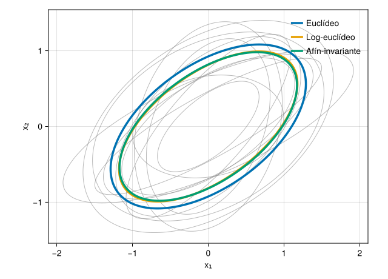

Figura 5.1: Doce matrices de $\mathrm{SPD}_2$ (elipses grises) y sus tres centros: euclídeo (media aritmética), log-euclídeo y afín-invariante. El centro euclídeo es el de mayor área.

```julia
colores = Makie.wong_colors()
rng_f = StableRNG(7)
Σ2 = spd2(2.0, 0.4, 0.5)
Ps2 = nube(rng_f, Σ2, 12, 0.7)
centros2 = [("Euclídeo", media_E(Ps2), colores[1]), ("Log-euclídeo", media_LE(Ps2), colores[2]), ("Afín-invariante", karcher(Ps2).M, colores[3])]
fig = Figure(size = (640, 460))
ax = Axis(fig[1, 1]; aspect = DataAspect(), xlabel = "x₁", ylabel = "x₂")
for P in Ps2
    E = ellipse(P); lines!(ax, E[1, :], E[2, :]; color = (:gray, 0.55), linewidth = 1)
end
for (nombre, M, c) in centros2
    E = ellipse(M); lines!(ax, E[1, :], E[2, :]; color = c, linewidth = 3.5, label = nombre)
end
axislegend(ax; position = :rt, framevisible = false)
fig
```

## 5.4 El espacio tangente y la vectorización isométrica

Los métodos estadísticos y de aprendizaje clásicos trabajan con vectores. La media de Karcher permite llevar el grupo a un espacio vectorial: cada $P_i$ se sustituye por su vector tangente en $M$. Para que la norma euclídea de ese vector sea la de Frobenius hay que declarar una convención:

**Proposición 5.5 (Vectorización isométrica)** Para $S\in\Sym_n$, sea $\operatorname{vec}(S)\in\R^{n(n+1)/2}$ el vector formado por los $S_{ii}$ y por los $\sqrt2\,S_{ij}$ con $i<j$. Entonces $\|\operatorname{vec}(S)\|_2=\|S\|_F$ y $\operatorname{vec}$ es lineal. Demostrado

*Demostración*. $\|S\|_F^2=\sum_iS_{ii}^2+2\sum_{i<j}S_{ij}^2=\sum_iS_{ii}^2+\sum_{i<j}(\sqrt2S_{ij})^2=\|\operatorname{vec}(S)\|_2^2$.

Sin el factor $\sqrt2$ las entradas fuera de la diagonal pesarían la mitad de lo que pesan en la norma de Frobenius. Se define $v_M(P)=\operatorname{vec}\big(\Logm(M^{-1/2}PM^{-1/2})\big)$, el **vector tangente en $M$** de $P$. Por la definición de $\dAI$, $\|v_M(P)\|_2=\dAI(M,P)$: las distancias a $M$ se conservan. Pero entre dos puntos cualesquiera $P,Q$, $\|v_M(P)-v_M(Q)\|_2$ no tiene por qué valer $\dAI(P,Q)$: es una **linealización** que distorsiona lo que está lejos de $M$.

**Código**

```julia
function vec_iso(S)
    n = size(S, 1)
    return [i == j ? S[i, j] : sqrt(2) * S[i, j] for i in 1:n for j in i:n]
end
tangente(M, P) = vec_iso(logm(blanquear(M, P)))

function experimento_distorsion(centros; pares = 80)
    rng = StableRNG(20261114)
    return map(centros) do c
        N = length(c.Ps)
        r = Float64[]
        while length(r) < pares
            i, j = rand(rng, 1:N, 2)
            i == j && continue
            push!(r, norm(tangente(c.M, c.Ps[i]) - tangente(c.M, c.Ps[j])) / dAI(c.Ps[i], c.Ps[j]))
        end
        (; s = c.s, mín = minimum(r), media = mean(r), máx = maximum(r))
    end
end
dist = experimento_distorsion(centros)
println("| \$s\$ | mínimo | media | máximo |\n|---|---|---|---|")
for d in dist
    println("| ", d.s, " | ", f3(d.mín), " | ", f3(d.media), " | ", f3(d.máx), " |")
end
println("\n: Razón \$\\|v_M(P)-v_M(Q)\\|_2/d_{AI}(P,Q)\$ entre pares de matrices del grupo, con \$M\$ la media de Karcher (80 pares por fila). {#tbl-distorsion}")
nothing
```

Tabla 5.2: Razón $\|v_M(P)-v_M(Q)\|_2/d_{AI}(P,Q)$ entre pares de matrices del grupo, con $M$ la media de Karcher (80 pares por fila).

| $s$ | mínimo | media | máximo |
| --- | --- | --- | --- |
| 0.1 | 0.997 | 0.999 | 1.0 |
| 0.3 | 0.975 | 0.992 | 0.997 |
| 0.6 | 0.916 | 0.969 | 0.989 |
| 1.0 | 0.791 | 0.939 | 0.98 |

La razón vale casi $1$ cuando el grupo está concentrado y baja al dispersarse ($0{,}79$ como mínimo con $s=1$), y no supera $1$ en ningún par (Tabla 5.2) Verificado numéricamente: la linealización **subestima** las distancias entre puntos lejanos. Es lo esperable con curvatura no positiva, donde las geodésicas se separan más rápido que en el plano [VERIFICAR fuente de la comparación]. La conclusión práctica es que el espacio tangente en la media es una buena aproximación mientras los datos estén cerca del centro, y que su calidad **depende de la dispersión**, que es justo lo que mide la varianza de Fréchet.

## 5.5 El re-centrado

Cuando las matrices vienen de sesiones distintas (otro montaje, otro día), un recurso habitual es **re-centrar** cada sesión en su propia media: $\varphi_M(P)=M^{-1/2}PM^{-1/2}$, que lleva $M$ a la identidad.

**Proposición 5.6 (El re-centrado es una isometría y borra una congruencia común salvo una rotación)**

1. $\varphi_M$ es una isometría de $(\SPD_n,\dAI)$ y $\varphi_M(M_{AI})=I$ si $M=M_{AI}$ de las $P_i$.
2. Sea $P_i'=WP_iW^\top$ con $W\in\GL(n)$ (una sesión que ve la misma actividad con otro montaje), $M=M_{AI}(P_i)$ y $M'=M_{AI}(P_i')=WMW^\top$. Entonces $R=M'^{-1/2}WM^{1/2}$ es ortogonal y
   $$\varphi_{M'}(P_i')=R\,\varphi_M(P_i)\,R^\top\qquad\text{para todo }i .$$
   Demostrado

*Demostración*.

1. Es la congruencia con $W=M^{-1/2}$ (Proposición 4.6), y $\varphi_M(M)=I$. (2) Por la Proposición 5.3, $M'=WMW^\top$. Entonces $RR^\top=M'^{-1/2}WM W^\top M'^{-1/2}=M'^{-1/2}M'M'^{-1/2}=I$, así que $R$ es ortogonal, y
   $$\varphi_{M'}(P_i')=M'^{-1/2}WP_iW^\top M'^{-1/2}=\big(M'^{-1/2}WM^{1/2}\big)\big(M^{-1/2}P_iM^{-1/2}\big)\big(M^{1/2}W^\top M'^{-1/2}\big)=R\,\varphi_M(P_i)\,R^\top .$$

Es decir, tras el re-centrado **dos sesiones que difieren por una congruencia común quedan iguales salvo una rotación $R$**. Como $\dAI$ es invariante por similitudes ortogonales, todas las distancias entre puntos de la misma sesión se conservan y las dos nubes tienen la misma forma. (El re-centrado es el análogo, en el espacio de matrices, del transporte paralelo del espacio tangente hasta la identidad [VERIFICAR fuente de la fórmula del transporte].) Lo que **no** hace es decidir qué rotación $R$ queda por alinear; eso es un problema aparte.

## 5.6 Experimento 2: remontaje de electrodos sin cambio cerebral

Con la misma nube de $N=30$ matrices de $\SPD_6$ ($s=0.4$) simulamos tres situaciones, todas con la misma realización aleatoria para no mezclar con el ruido de estimación (capítulo 3): **(a)** remontaje: la misma actividad vista con otras ganancias y una mezcla suave, $P_i'=WP_iW^\top$; **(b)** más dispersión: la misma media teórica, con los desplazamientos respecto de ella multiplicados por $1{,}5$; **(c)** las dos cosas.

**Código**

```julia
function experimento_remontaje(; n = 6, N = 30)
    rng = StableRNG(20261115)
    Σ = spd_kappa(rng, n, 10)
    G = [simetrica(rng, n) for _ in 1:N]
    P1 = nube(rng, Σ, N, 0.4; G = G)
    W = Diagonal(exp.(0.4 .* randn(rng, n))) * (I + 0.2 * randn(rng, n, n))
    cg(P) = symmetrize(W * P * W')
    M1 = karcher(P1).M
    casos = [("(a) Remontaje", cg.(P1)), ("(b) Más dispersión", nube(rng, Σ, N, 0.6; G = G)),
             ("(c) Remontaje y más dispersión", cg.(nube(rng, Σ, N, 0.6; G = G)))]
    filas = map(casos) do (nombre, P2)
        M2 = karcher(P2).M
        (; nombre, E = norm(M1 - M2), LE = norm(logm(M1) - logm(M2)), AI = dAI(M1, M2),
           rec = dAI(blanquear(M1, M1), blanquear(M2, M2)), σ1 = varianza(M1, P1), σ2 = varianza(M2, P2))
    end
    # comprobación de la @prp-recentrado en el caso (a)
    P2 = cg.(P1); M2 = karcher(P2).M
    R = invsqrtm(M2) * W * sqrtm(M1)
    ajuste = maximum(norm(blanquear(M2, P2[i]) - R * blanquear(M1, P1[i]) * R') / norm(blanquear(M2, P2[i])) for i in 1:N)
    return filas, norm(R * R' - I), ajuste
end
filas_r, ortogonalidad, ajuste = experimento_remontaje()
println("| Situación | \$d_E(M_1,M_2)\$ | \$d_{LE}\$ | \$d_{AI}\$ | \$d_{AI}\$ tras re-centrar | \$\\sigma^2_{AI}\$ sesión 1 | \$\\sigma^2_{AI}\$ sesión 2 |\n|---|---|---|---|---|---|---|")
for f in filas_r
    println("| ", f.nombre, " | ", f3(f.E), " | ", f3(f.LE), " | ", f3(f.AI), " | ", f3(f.rec), " | ", f3(f.σ1), " | ", f3(f.σ2), " |")
end
println("\n: Distancias entre las medias de dos sesiones y varianza de Fréchet, antes y después del re-centrado. {#tbl-remontaje}\n")
println("Comprobación de la @prp-recentrado en el caso (a): \$\\|RR^\\top-I\\|_F=$(f3(ortogonalidad))\$ y error relativo máximo \$\\varphi_{M'}(P_i')\$ frente a \$R\\varphi_M(P_i)R^\\top\$ de \$$(f3(ajuste))\$.")
nothing
```

Tabla 5.3: Distancias entre las medias de dos sesiones y varianza de Fréchet, antes y después del re-centrado.

| Situación | $d_E(M_1,M_2)$ | $d_{LE}$ | $d_{AI}$ | $d_{AI}$ tras re-centrar | $\sigma^2_{AI}$ sesión 1 | $\sigma^2_{AI}$ sesión 2 |
| --- | --- | --- | --- | --- | --- | --- |
| (a) Remontaje | 17.8 | 3.4 | 3.52 | 1.11e-14 | 3.29 | 3.29 |
| (b) Más dispersión | 0.696 | 0.133 | 0.137 | 4.16e-15 | 3.29 | 7.42 |
| (c) Remontaje y más dispersión | 17.2 | 3.35 | 3.47 | 5.99e-15 | 3.29 | 7.42 |

Comprobación de la Proposición 5.6 en el caso (a): $\|RR^\top-I\|_F=1.47e-14$ y error relativo máximo $\varphi_{M'}(P_i')$ frente a $R\varphi_M(P_i)R^\top$ de $1.85e-15$.

La Tabla 5.3 cuenta tres cosas Verificado numéricamente:

- **El remontaje (a) mueve las tres medias** (las tres distancias son grandes), pero no cambia la varianza de Fréchet afín-invariante (Proposición 5.3: $\sigma^2$ es invariante por congruencia). Tras el re-centrado las dos medias coinciden con la identidad (la distancia es cero hasta el error numérico), y las nubes quedan iguales salvo la rotación $R$, como dice la Proposición 5.6.
- **El cambio de dispersión (b) no lo toca el re-centrado**: las medias apenas se mueven y la varianza de Fréchet sube de forma visible. Esa diferencia sobrevive porque no es una congruencia.
- **El re-centrado borra todo desplazamiento de la media**, también el fisiológico. Matemáticamente, un cambio real en la covarianza media $\Sigma\to A\Sigma A^\top$ y un remontaje con $W=A$ producen la misma nube y son indistinguibles (la situación (2) frente a la (3) del capítulo 4). Re-centrar es, por tanto, una decisión con coste: se pierde la **localización** y se conserva la **dispersión y la forma**.

## 5.7 Lo que esto no demuestra

- **No demuestra que un centro sea mejor que otro.** Describe qué propiedades tiene cada uno. Con qué centro se detectan mejor las diferencias entre grupos depende del tipo de efecto y de $T/n$, y se estudia en el capítulo 6.
- **La unicidad y la caracterización de la media afín-invariante son resultados citados**, no demostrados aquí. El algoritmo de punto fijo se ha comprobado en los ejemplos, no se ha demostrado que converja siempre.
- **La distorsión del espacio tangente se ha medido, no acotado.** La razón $\le1$ es una observación numérica en matrices de tamaño $6$ con dispersión simétrica; no hay una cota general en este capítulo.
- **El experimento de remontaje es determinista a propósito:** usa la misma realización aleatoria para aislar el efecto de la congruencia. Con muestras independientes en cada sesión (capítulo 3) las nubes coinciden solo aproximadamente tras el re-centrado.
- **No se estima la rotación residual $R$.** Alinear dos sesiones re-centradas exige además estimarla, con datos y con hipótesis que no se han tratado.
- **La media de Fréchet depende de $N$ y de la dispersión de las matrices.** No se ha estudiado su error de estimación ni su sesgo; tampoco la mediana, que se deja como ejercicio.

## 5.8 Autoevaluación

**TipPromediar covarianzas**

Se tienen cien matrices de covarianza de épocas de una persona. ¿Qué diferencia hay entre su media aritmética y su media afín-invariante en cuanto al volumen (determinante)?

**Respuesta.** La media afín-invariante tiene como determinante la media geométrica de los determinantes; el de la aritmética es mayor o igual, con igualdad solo si todas las matrices son iguales (Proposición 5.4). La aritmética infla el volumen.

**TipDos montajes distintos**

Dos sesiones difieren solo por una congruencia común. Se re-centra cada una en su media y se comparan las medias. ¿Qué vale su distancia, y qué queda sin comparar?

**Respuesta.** Cero, porque ambas medias son la identidad. Queda por alinear una rotación $R$ (Proposición 5.6), y se ha perdido toda la información de localización, incluida la fisiológica.

**TipUn solo número de dispersión**

La varianza de Fréchet afín-invariante de una sesión no cambia al remontar los electrodos. ¿Es esa la razón de que sirva para comparar sesiones?

**Respuesta.** Es una condición necesaria, no suficiente: no cambia por una congruencia común (Proposición 5.3), pero tampoco distingue un cambio de dispersión instrumental que no sea una congruencia (ganancias que varían entre épocas), ni dice nada sobre incertidumbre de estimación (capítulo 3).

## 5.9 Ejercicios

**Ejercicio 5.1** Demuestra que para $N=2$ la media de Karcher es el punto medio $\gamma_{AI}(\tfrac12)=P_1\#P_2$ del capítulo 4.

**TipPista**

Comprueba que $P_1\#P_2$ cumple la ecuación 5.2 usando $\Logm(C^{1/2})=\tfrac12\Logm C$ y $\Logm(C^{-1})=-\Logm C$.

**Ejercicio 5.2** Para $n=1$, calcula las tres medias de Fréchet de $a_1,\dots,a_N>0$ y comprueba que la afín-invariante y la log-euclídea coinciden en la media geométrica.

**Ejercicio 5.3** (Laboratorio) La **mediana geométrica** minimiza $\sum_i\dAI(M,P_i)$ (sin elevar al cuadrado). Propón y programa una iteración tipo Weiszfeld en el espacio tangente, y compara su resistencia a un dato anómalo con la de la media de Karcher.

**Ejercicio 5.4** Con las funciones `nube`, `karcher` y `varianza` del laboratorio, estima cómo crece la varianza de Fréchet con $s$ y con $n$. ¿Se parece a $s^2\,n(n+1)/2$?

**Ejercicio 5.5** Repite el Experimento 2 (a) generando las dos sesiones con covarianzas muestrales independientes (capítulo 3). Mide, tras re-centrar, la distancia afín-invariante entre las nubes de las dos sesiones una vez rotada la segunda con la mejor rotación ortogonal (Procrustes), y relaciónala con el suelo de ruido.

Bhatia, Rajendra. 2007. *Positive Definite Matrices*. Princeton Series en Applied Mathematics. Princeton University Press.

Carmo, Manfredo P. do. 1992. *Riemannian Geometry*. Birkhäuser.

Karcher, Hermann. 1977. «Riemannian center of mass and mollifier smoothing». *Communications on Pure and Applied Mathematics* 30 (5): 509-41. https://doi.org/10.1002/cpa.3160300502.

Lee, John M. 2018. *Introduction to Riemannian Manifolds*. 2.ª ed. Springer.

Moakher, Maher. 2005. «A Differential Geometric Approach to the Geometric Mean of Symmetric Positive-Definite Matrices». *SIAM Journal on Matrix Analysis and Applications* 26 (3): 735-47. https://doi.org/10.1137/S0895479803436937.